# Examining NY Times’s COVID-19 Data

The NY Times publishes US-county-level counts of COVID-19 cases and deaths daily on [github](https://github.com/nytimes/covid-19-data). This notebook combines this data with the estimated population data from the US census to identify areas with high ratios of COVID-19 cases (aka “hotspots”)

First, let’s read in the COVID-19 data from the NY Times. Each county is identified by a [FIPS code](https://en.wikipedia.org/wiki/FIPS_county_code).

```r
library(tidyverse)

col_types <- cols(
  date = col_date(format = ""),
  county = col_character(),
  state = col_character(),
  fips = col_integer(),
  cases = col_double(),
  deaths = col_double()
)
df_cases <- read_csv('./us-counties.csv', col_types=col_types)
```

Let’s read in the population data from the US census. It requires some munging to create a FIPS column, which is required for this data to be combined with the NY Times data,

```r
col_types <- cols(
  .default = col_double(),
  SUMLEV = col_character(),
  STATE = col_integer(),
  COUNTY = col_integer(),
  STNAME = col_character(),
  CTYNAME = col_character()
)

df_pop <- read_csv('./co-est2019-alldata.csv', col_types=col_types) %>%
    select( "COUNTY", "STATE", "POPESTIMATE2019") %>%
    mutate(fips=STATE*1000 + COUNTY) %>%
    select("fips", POPESTIMATE2019)
```

Merge it into the NY Times data by the shared column, fips,

```r
df_cases <- left_join(df_cases, df_pop, by="fips")
```

Let’s add a new column that is the ratio of COVID-19 cases to each county’s population. Counties with a high ratio could be classified as a hotspot. Note that the NYC counties (King’s, Queen’s, etc.) are a hotspot right now but are missing. That’s because the NY Times has chosen to break NYC’s data out separately.

Let’s print out the top 100 counties with the highest ratio,

```r
df_cases <- df_cases %>%
    mutate(ratio = cases/POPESTIMATE2019)

df_cases %>%
    arrange(desc(date), desc(ratio)) %>%
    top_n(100)
```

| date | county | state | fips | cases | deaths | POPESTIMATE2019 | ratio |
| --- | --- | --- | --- | --- | --- | --- | --- |
| 2020-03-30 | Westchester | New York | 36119 | 9326 | 19 | 967506 | 0.009639217 |
| 2020-03-30 | Rockland | New York | 36087 | 2511 | 8 | 325789 | 0.007707443 |
| 2020-03-30 | Blaine | Idaho | 16013 | 148 | 2 | 23021 | 0.006428913 |
| 2020-03-30 | Nassau | New York | 36059 | 7344 | 48 | 1356924 | 0.005412241 |
| 2020-03-30 | Gunnison | Colorado | 8051 | 80 | 1 | 17462 | 0.004581377 |
| 2020-03-30 | Summit | Utah | 49043 | 176 | 0 | 42145 | 0.004176059 |
| 2020-03-30 | Suffolk | New York | 36103 | 5791 | 44 | 1476601 | 0.003921845 |
| 2020-03-30 | Eagle | Colorado | 8037 | 213 | 4 | 55127 | 0.003863805 |
| 2020-03-30 | Orleans | Louisiana | 22071 | 1480 | 86 | 390144 | 0.003793471 |
| 2020-03-30 | Orange | New York | 36071 | 1435 | 3 | 384940 | 0.003727854 |

[output cut: 90 more lines]

Let’s plot the cases vs. time a few of the hotspots. Are any of them showing a deceleration in the number of cases?

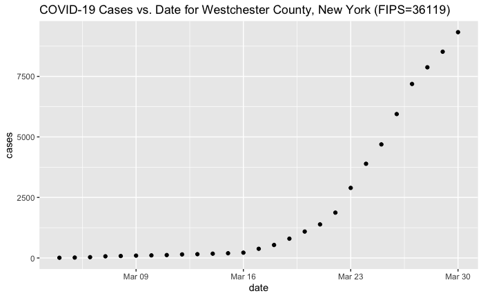

```r
library(ggplot2)

plotCases <- function(f) {
    data <- df_cases %>% filter(fips==f)
    elem <- (data %>% slice(1))
    ggplot(data, aes(date, cases)) + geom_point() + ggtitle(sprintf('COVID-19 Cases vs. Date for %s County, %s (FIPS=%d)',
        elem$county, elem$state, elem$fips))
}

plotCases(36119)
```

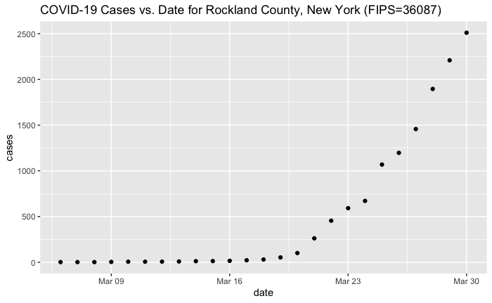

```r
plotCases(36087)
```

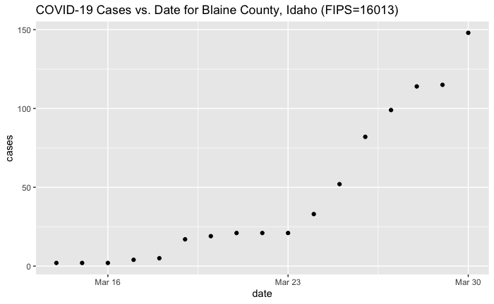

```r
plotCases(16013)
```

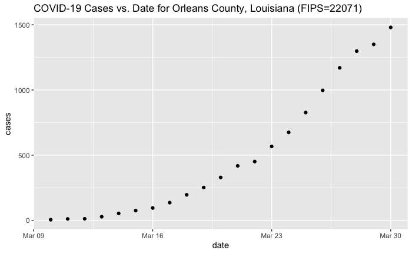

```r
plotCases(22071)
```

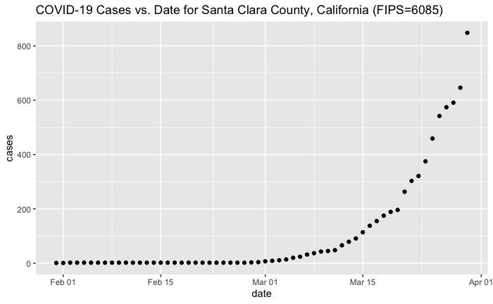

```r
# a few place of personal interest
plotCases(6085)
```

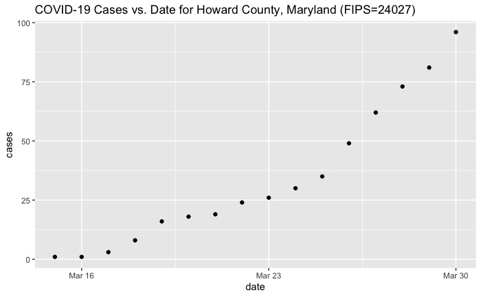

```r
plotCases(24027)
```

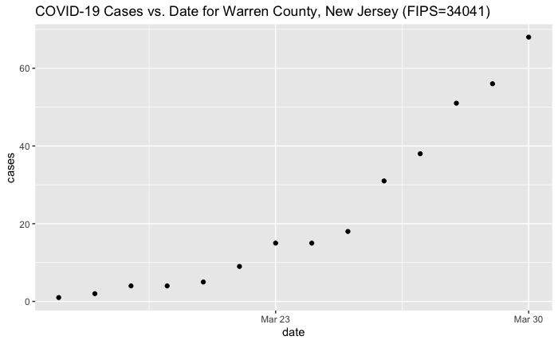

```r
plotCases(34041)
```

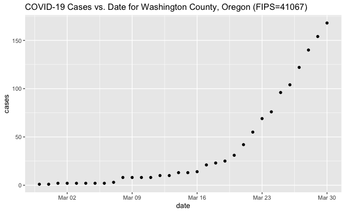

```r
plotCases(41067)
```

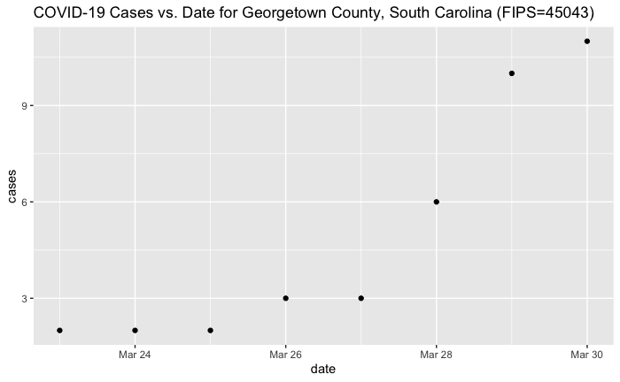

```r
plotCases(45043)
```